# COD Reproducibility Report

#### Article ID: DvcDF

#### Pilot: Sara Altman

#### Co-pilot: Tom Hardwicke

#### Start date: 04/07/2017

#### End date: 07/16/2017

#### Methods summary:

The experimenters tested sixty-two participants. Half were monolingual and half were bilingual. The experimenters gave the participants working memory and non-verbal reasoning tasks to ensure that the bilingual and monolingual groups were similar in terms of cognitive functioning. Working memory was assessed using the Wechsler Adult Intelligence Scale IV. Non-verbal reasoning was assessed using the Raven’s Advanced Progressive Matrices. The experimenter’s also checked the English language proficiency of the bilinguals.

To measure metacognitive performance, the experimenters administered a dot discrimination task. In the dot discrimination task, participants were presented with two white circles on a black background. The participants were asked to choose which circle contained the most dots within it’s boundary. The differences in dot numbers were modified with a staircase procedure so that accuracy was normalised at 71%. Participants completed 8 blocks of the dot discrimination task, each with 25 trials.

#### Target outcomes:

The experimenters conducted a t-test to compare the bilinguals’ and monolinguals’ choice response time in the dot discrimination task.

> We compared the bilinguals’ and monolinguals’ performance with regard to their first order accuracy (measured by percentage of correct responses), the difficulty of the trials (measured by dot difference) and response time of the choice and the confidence judgment (both measured in seconds). The results of all these anal- yses are summarised in Table 3. The monolingual group had a mean accuracy of 70.98%, with a standard deviation of 1.06%, whilst the bilingual group had mean accuracy of 70.79% with a standard deviation of 1.23%. This indi- cates that the staircase procedure successfully standardised accu- racy across participants. There were no significant group differences with regard to trial difficulty, with a mean dot differ- ence of 4.64 for the monolinguals and 4.34 for the bilinguals. Addi- tionally, with regards to response time for the confidence judgments there was no difference between the groups: the mono-lingual group took, on average, 1179 ms to respond compared to 1112 ms for the bilinguals. However, the groups did differ with regards to choice response time; an independent samples t-test showed that bilinguals (M = 2679 ms, SD = 923 ms) were significantly faster than mono- linguals (M = 3360 ms, SD = 1475 ms, t(50.38) = 2.18, p = .03, d = 0.55). A random slopes multilevel model (MLM) revealed that this relationship was significantly mediated by block (see Fig. 3; for more detailed information about the MLM fitting see Appendix A). Monolinguals were set to be the reference category for this analysis and all subsequent MLMs. The model tells us that the main-effect of group became statistically non-significant when the block-group interaction was accounted for (b = 283.11, t (64.03) = 0.71, p = 0.48). The main effect of block was also non- significant (b = 19.23, t(64.03) = 0.61, p = 0.54), meaning that the response speed of the monolinguals did not change significantly over time, when individual variation in intercepts and slopes were accounted for. The bilingual group ⁄ block interaction was signifi- cant (b = 88, t(64.03) = 2.01, p = .05), meaning that bilinguals, as a group, became faster as the task progressed. Two participants in the monolingual group displayed outlying values for one variable (difficulty and response time, respectively). In order to ensure that these outliers did not unduly influence the group-wise comparisons they were both capped at 3 standard deviations above the group mean. Capping these values did not change the results for difficulty (t(59.78) = 1.29, p = .20, d = 0.33) or for response time (t(55.17) = 2.24, p = .03, d = 0.57).

## Step 1: Load packages

[Some useful packages are being loaded below. You can add any additional ones you might need too.]

```r
library(tidyverse) # for data munging
library(knitr) # for kable table formating
library(haven) # import and export 'SPSS', 'Stata' and 'SAS' Files
library(readxl) # import excel files
library(CODreports) # custom report functions
library(readr)
library(lsr)
library(lme4)
library(stringr)
library(pbkrtest)

data_file <- "~/GitHub/skaltman/set_DvcDF/data/data.xlsx"
rename_all <- function(df, fun){
  setNames(df, fun(names(df)))
  }
```

## Step 2: Load data

```r
column_names <- c("id",
                  "group",
                  "first_accuracy",
                  "first_rt",
                  "first_dot_diff",
                  "second_confidence",
                  "second_mratio",
                  "mratio_1",
                  "mratio_2",
                  "rt_1",
                  "rt_2",
                  "rt_3",
                  "rt_4",
                  "rt_5",
                  "rt_6",
                  "rt_7",
                  "rt_8")


#I recalculated the average reaction times because the ones given were rounded
data <- read_excel(data_file, sheet = 2, skip = 2, col_names = column_names) %>%
  mutate(first_rt = (rt_1 + rt_2 + rt_3 + rt_4 + rt_5 + rt_6 + rt_7 + rt_8)/8)

demographics <-
  read_excel(data_file, sheet = 1) %>%
  rename_all(tolower) %>%
  rename(id = `participant id`) %>%
  filter(!is.na(id))
```

## Step 3: Tidy data

```r
data_tidy <-
  data %>%
  group_by(id) %>%
  gather(key = "measure", value = "value", first_accuracy:rt_8)
```

## Step 4: Run analysis

### Pre-processing

> Two participants in the monolingual group displayed outlying values for one variable (difficulty and response time, respectively). In order to ensure that these outliers did not unduly influence the group-wise comparisons they were both capped at 3 standard deviations above the group mean. Capping these values did not change the results for difficulty (t(59.78) = 1.29, p = .20, d = 0.33) or for response time (t(55.17) = 2.24, p = .03, d = 0.57).

The following code chunk confirms that there are two participants in the monolingual group with outlying values for one variable (difficulty and response time).

```r
mean_diff = mean(data$first_dot_diff, na.rm = TRUE)
sd_diff = sd(data$first_dot_diff, na.rm = TRUE)
mean_rt = mean(data$first_rt, na.rm = TRUE)
sd_rt = sd(data$first_rt, na.rm = TRUE)

data_tidy %>%
  spread(key = measure, value = value) %>%
  filter(first_dot_diff > mean_diff + 3*sd_diff | first_rt > mean_rt + 3*sd_rt)
```

```
## # A tibble: 2 x 17
## # Groups:   id [2]
##      id       group first_accuracy first_dot_diff first_rt mratio_1
##   <dbl>       <chr>          <dbl>          <dbl>    <dbl>    <dbl>
## 1     9 Monolingual           0.70           7.57  2.21625     0.69
## 2    24 Monolingual           0.72           3.96  9.49875     0.55
## # ... with 11 more variables: mratio_2 <dbl>, rt_1 <dbl>, rt_2 <dbl>,
## #   rt_3 <dbl>, rt_4 <dbl>, rt_5 <dbl>, rt_6 <dbl>, rt_7 <dbl>,
## #   rt_8 <dbl>, second_confidence <dbl>, second_mratio <dbl>
```

This code chunk caps the values as specified in the original paper and performs the t-test:

```r
data_tidy_capped <-
  data_tidy %>%
  spread(key = measure, value = value) %>%
  mutate(first_dot_diff = ifelse(first_dot_diff > mean_diff + 3*sd_diff,
                                 mean_diff + 3*sd_diff,
                                 first_dot_diff),
         first_rt = ifelse(first_rt > mean_rt + 3*sd_rt,
                                 mean_rt + 3*sd_rt,
                                 first_rt))

monolingual_capped <-
  data_tidy_capped %>%
  filter(group == "Monolingual")

bilingual_capped <-
  data_tidy_capped %>%
  filter(group == "Bilingual")

t_test_rt_capped <- t.test(x = monolingual_capped$first_rt,
                           y = bilingual_capped$first_rt)
d_rt_capped <- cohensD(x = monolingual_capped$first_rt,
                       y = bilingual_capped$first_rt)
t_test_diff_capped <- t.test(x = monolingual_capped$first_dot_diff,
                             y = bilingual_capped$first_dot_diff)
d_diff_capped <- cohensD(x = monolingual_capped$first_dot_diff,
                         y = bilingual_capped$first_dot_diff)

t_tests_capped <-
  tibble(
    measure = c("Response time", "Difficulty"),
    t = c(abs(t_test_rt_capped$statistic), abs(t_test_diff_capped$statistic)),
    df = c(t_test_rt_capped$parameter, t_test_diff_capped$parameter),
    p = c(t_test_rt_capped$p.value, t_test_diff_capped$p.value),
    d = c(d_rt_capped, d_diff_capped)
  )

kable(t_tests_capped, digits = 2)
```

| measure | t | df | p | d |
| --- | --- | --- | --- | --- |
| Response time | 2.25 | 57.43 | 0.03 | 0.57 |
| Difficulty | 1.31 | 59.73 | 0.20 | 0.33 |

The t-value for difficulty is slightly off. As are the degrees of freedom. The Cohen’s d values are the same as originally reported, as are the p-values.

I compare the reported t-value and the calculated t-values for response time:

```r
compareValues(reportedValue = 2.24, obtainedValue = 2.25)
```

```
## [1] "MINOR NUMERICAL ERROR. The reported value (2.24) and the obtained value (2.25) differed by 0.45%"
```

Then the reported and calculated t-values for difficulty:

```r
compareValues(reportedValue = 1.29, obtainedValue = 1.31)
```

```
## [1] "MINOR NUMERICAL ERROR. The reported value (1.29) and the obtained value (1.31) differed by 1.55%"
```

### Descriptive statistics

Table 3 from the original paper provides all descriptive statistics computed.

> here were no significant group differences with regard to trial difficulty, with a mean dot differ- ence of 4.64 for the monolinguals and 4.34 for the bilinguals.

However, the table says the mean dot difference for monolinguals is 4.33, and the mean dot difference for bilinguals is 4.64.

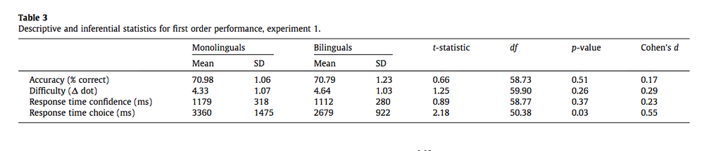

The following code chunk recreates this table:

```r
#Mean and sd accuracies for mono- and bilinguals
accuracy_tibble <-
  data_tidy %>%
  filter(measure == "first_accuracy") %>%
  group_by(group) %>%
  summarise(mean_accuracy = mean(value*100, na.rm = TRUE),
            sd_accuracy = sd(value*100, na.rm = TRUE)) %>%
  arrange(desc(group))

#difficulty mean and sd for mono- and bilinguals
dot_diff_tibble <-
  data_tidy %>%
  filter(measure == "first_dot_diff") %>%
  group_by(group) %>%
  summarise(mean_dot_diff = mean(value, na.rm = TRUE),
            sd_dot_diff = sd(value, na.rm = TRUE)) %>%
  arrange(desc(group))

#response time confidence mean and sd for mono- and bilinguals
confidence_tibble <-
  data_tidy %>%
  filter(measure == "second_confidence") %>%
  group_by(group) %>%
  summarise(mean_confidence_rt = mean(value * 1000, na.rm = TRUE),
            sd_confidence_rt = sd(value * 1000, na.rm = TRUE)) %>%
  arrange(desc(group))

#response time choice mean and sd for mono- and bilinguals
rt_tibble <-
  data_tidy %>%
  filter(measure == "first_rt") %>%
  group_by(group) %>%
  summarise(mean_choice_rt = mean(value*1000, na.rm = TRUE),
            sd_choice_rt = sd(value*1000, na.rm = TRUE)) %>%
  arrange(desc(group))

#creates tibble of all values
all_measures <-
  accuracy_tibble %>%
  left_join(dot_diff_tibble, by = "group") %>%
  left_join(confidence_tibble, by = "group") %>%
  left_join(rt_tibble, by = "group")

monolingual <-
  all_measures %>%
  filter(group == "Monolingual")

bilingual <-
  all_measures %>%
  filter(group == "Bilingual")

t_test_accuracy = t.test(x = data_tidy %>%
                             filter(group == "Monolingual", measure == "first_accuracy") %>%
                             .$value,
                         y = data_tidy %>%
                             filter(group == "Bilingual", measure == "first_accuracy") %>%
                             .$value)

t_test_difficulty = t.test(x = data_tidy %>%
                             filter(group == "Monolingual", measure == "first_dot_diff") %>%
                             .$value,
                         y = data_tidy %>%
                             filter(group == "Bilingual", measure == "first_dot_diff") %>%
                             .$value)

t_test_confidence = t.test(x = data_tidy %>%
                             filter(group == "Monolingual", measure == "second_confidence") %>%
                             .$value,
                         y = data_tidy %>%
                             filter(group == "Bilingual", measure == "second_confidence") %>%
                             .$value)

t_test_rt <- t.test(x = data_tidy %>%
                      filter(group == "Monolingual", measure == "first_rt") %>%
                      .$value,
                    y = data_tidy %>%
                      filter(group == "Bilingual", measure == "first_rt") %>%
                      .$value)

cohens_d_accuracy = cohensD(x = data_tidy %>%
                             filter(group == "Monolingual", measure == "first_accuracy") %>%
                             .$value,
                         y = data_tidy %>%
                             filter(group == "Bilingual", measure == "first_accuracy") %>%
                             .$value)

cohens_d_difficulty = cohensD(x = data_tidy %>%
                             filter(group == "Monolingual", measure == "first_dot_diff") %>%
                             .$value,
                         y = data_tidy %>%
                             filter(group == "Bilingual", measure == "first_dot_diff") %>%
                             .$value)

cohens_d_confidence = cohensD(x = data_tidy %>%
                             filter(group == "Monolingual", measure == "second_confidence") %>%
                             .$value,
                         y = data_tidy %>%
                             filter(group == "Bilingual", measure == "second_confidence") %>%
                             .$value)

cohens_d_rt <- cohensD(x = data_tidy %>%
                         filter(group == "Monolingual", measure == "first_rt") %>%
                         .$value,
                       y = data_tidy %>%
                         filter(group == "Bilingual", measure == "first_rt") %>%
                         .$value)

summary_tibble <-
  tibble(measure = c("Accuracy (% correct)", "Difficulty",
                   "Response time confidence (ms)", "Response time choice (ms)"),
         `Monolinguals Mean` = c(monolingual$mean_accuracy,
                                  monolingual$mean_dot_diff,
                                  monolingual$mean_confidence_rt,
                                  monolingual$mean_choice_rt),
         `Monolinguals SD` = c(monolingual$sd_accuracy,
                                 monolingual$sd_dot_diff,
                                 monolingual$sd_confidence_rt,
                                 monolingual$sd_choice_rt),
         `Bilinguals Mean` = c(bilingual$mean_accuracy,
                                 bilingual$mean_dot_diff,
                                 bilingual$mean_confidence_rt,
                                 bilingual$mean_choice_rt),
          `Bilinguals SD` = c(bilingual$sd_accuracy,
                                bilingual$sd_dot_diff,
                                bilingual$sd_confidence_rt,
                                bilingual$sd_choice_rt),
         `t-statistic` = c(t_test_accuracy$statistic, t_test_difficulty$statistic,
                           t_test_confidence$statistic, t_test_rt$statistic),
         df = c(t_test_accuracy$parameter, t_test_difficulty$parameter,
                t_test_confidence$parameter, t_test_rt$parameter),
         `p-value` = c(t_test_accuracy$p.value, t_test_difficulty$p.value,
                t_test_confidence$p.value, t_test_rt$p.value),
         `Cohen's d` = c(cohens_d_accuracy, cohens_d_difficulty,
                         cohens_d_confidence, cohens_d_rt))

kable(summary_tibble, digit = 2)
```

| measure | Monolinguals Mean | Monolinguals SD | Bilinguals Mean | Bilinguals SD | t-statistic | df | p-value | Cohen’s d |
| --- | --- | --- | --- | --- | --- | --- | --- | --- |
| Accuracy (% correct) | 71.29 | 1.07 | 71.03 | 1.30 | 0.85 | 57.82 | 0.40 | 0.22 |
| Difficulty | 4.31 | 0.97 | 4.64 | 1.03 | -1.29 | 59.78 | 0.20 | 0.33 |
| Response time confidence (ms) | 1179.35 | 318.36 | 1111.29 | 275.74 | 0.90 | 58.80 | 0.37 | 0.23 |
| Response time choice (ms) | 3359.35 | 1474.61 | 2679.35 | 923.39 | 2.18 | 50.39 | 0.03 | 0.55 |

All values provided in the orginal table match those provided in the text of the original paper, except for the following exceptions:

- Mean dot difference for monolinguals. The original table states that the value is 4.33. The original text says:

> There were no significant group differences with regard to trial difficulty, with a mean dot differ- ence of 4.64 for the monolinguals…
- Mean dot difference for bilinguals. The original table states that the value is 4.64. The original text says:

> There were no significant group differences with regard to trial difficulty, with a mean dot differ- ence of 4.64 for the monolinguals and 4.34 for the bilinguals.
- Standard deviation of choice response time for bilinguals. The text says:

> However, the groups did differ with regards to choice response time; an independent samples t-test showed that bilinguals (M = 2679 ms, SD = 923 ms)…

For these discrepancies, I will compare my obtained values to those in the table and in the text.